[output not shown]

```r
library(biodyn)
```

# Introduction

Methods are including for fitting, examining goodness of fit diagnostics, estimating uncertainly in stock status relative to reference points, running projections and Harvest Control Rules (HCRs) and conducting Management Strategy Evaluation (MSE).

## Stock assessment

The dynamics i.e. productivity and reference points and the response of the stock to perturbations, are determined by $r$ and the shape of the production function $p$. if $p=1$ then MSY is found halfway between 0 and K; as p increases MSY shifts to the right.

Since there is insuffcient infomation in the catch data to estimate the few parameters of the production function additional data, e.g. time series of relative abundance from catch per unit effort (CPUE) or surveys are required for calibration.

Although knowledge about these processes affects the ability to provide robust scientific the main objective of fisheries management is not to provide the best model of population dynamics but to manage fishing. For example a Pella-Tomlinson surplus production function is used to set catch limits for Baleen whales by the IWC. However, neither the form of model nor its parameter are meant to provide an accurate representation of the dynamics of the population. Rather, it has been demonstrated by MSE that when used as an integral part of a management strategy with an HCRs it allows the robust calculation and setting of catches limits.

# The Class

biodyn has slots for the catch, parameter estimates, fitted stock biomass and residuals from the fits of the CPUE used as proxies for stock biomass. There are a variety of methods for deriving quantities used in management such as reference points and for plotting. First an object of class biodyn has to be created

## Creating an object

There are various ways of creating a new object, the obvious way is to use the class creator

```r
bd = biodyn()
```

Supplying an argument such as the catch helps to set the dimensions

```r
bd = biodyn(catch = FLQuant(100, dimnames = list(year = 1990:2010)))
```

But the easist way is to create an new object is from an existing one, i.e. coercion.

From aspic

```r
library(aspic)
asp = aspic("http://http://rscloud.iccat.int/kobe/swon/2013/aspic/run2/")
bd = as(asp, "biodyn")
```

or FLStock

```r
data(ple4)
bd = as(ple4, "biodyn")
```

# Plotting

Plotting can be used to examine an object, explore data, check outputs, diagnose problems, and summarise results. biodyn uses ggplot2 as this allows a variety of basic plots to be provided as part of the package and then for these to be modified and new plots developed as required.

## Time Series

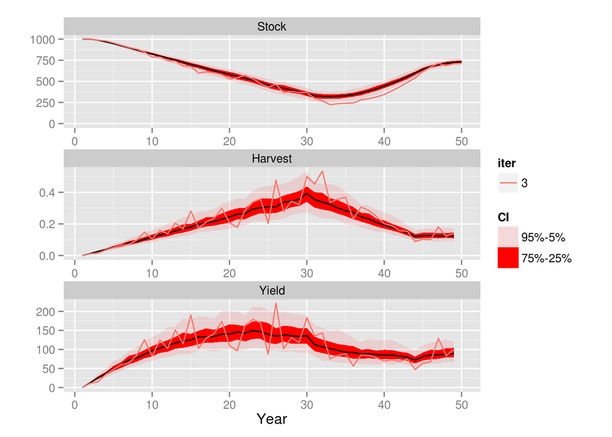

```r
x = simBiodyn()
x = window(x, end = 49)
x = fwd(x, harvest = rlnorm(200, log(harvest(x)[, -1]), 0.2))
plot(x, worm = 3)
```

## Equilibrium Plots and Reference Points

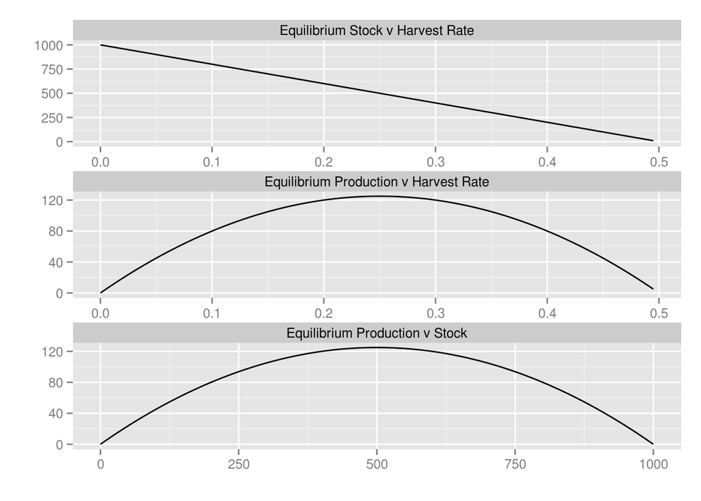

```r
plotEql(x)
```

## Production Function

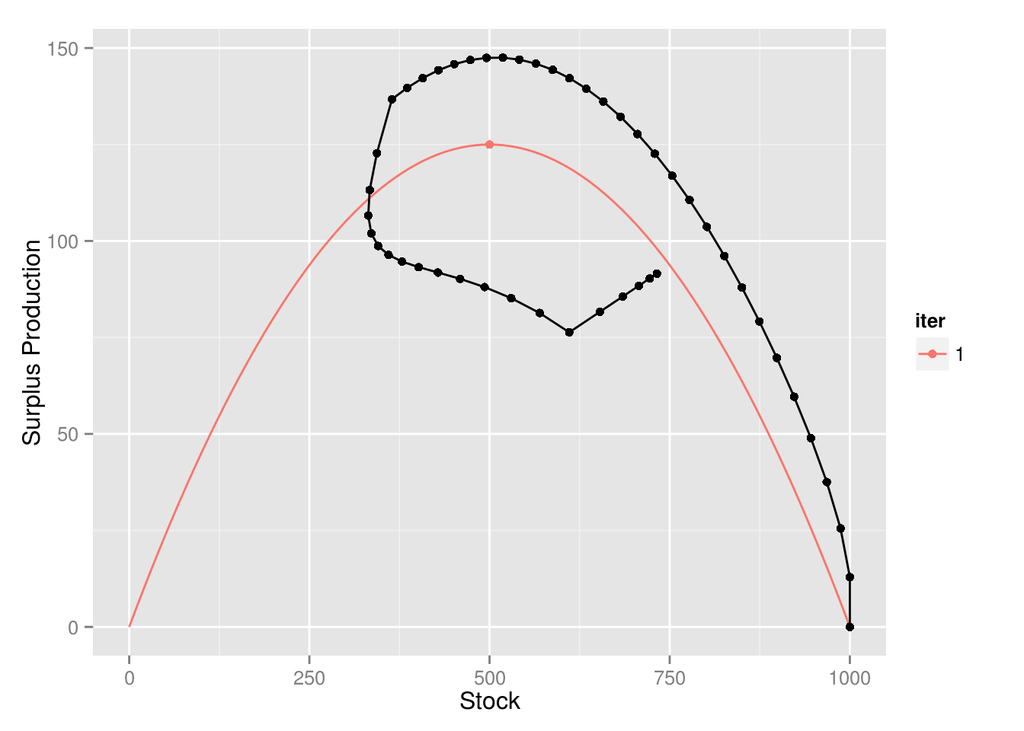

```r
x = simBiodyn()
plotPrd(x) + geom_path(aes(stock, catch), model.frame(FLQuants(x, "stock", "catch"))) +
    geom_point(aes(stock, catch), model.frame(FLQuants(x, "stock", "catch")))
```

## Comparisons with other classes

# Estimation

It is alway good to check estimated values with the true ones. However, draining even the North Sea to count the cod is difficult let alone draining the Atlantic to count tuna so instead we simulate a stock with know parameters and exploitation history

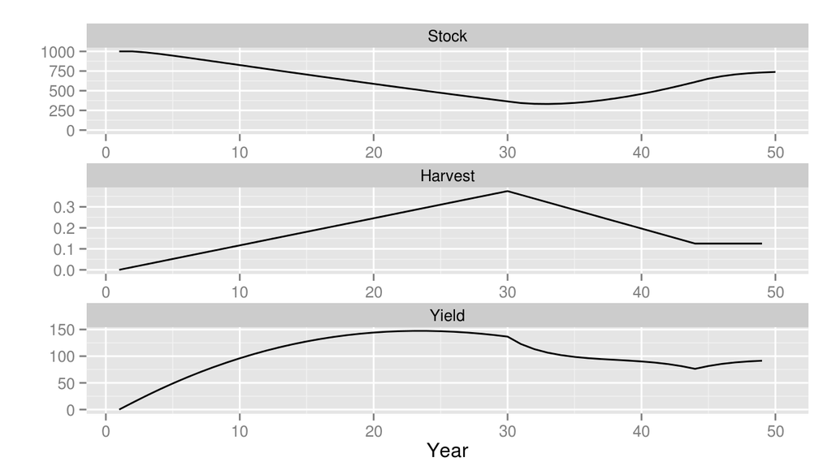

```r
bd = simBiodyn()

plot(bd)
```

We also need a CPUE series so we simulate that by taking the mid year biomass and adding an error term.

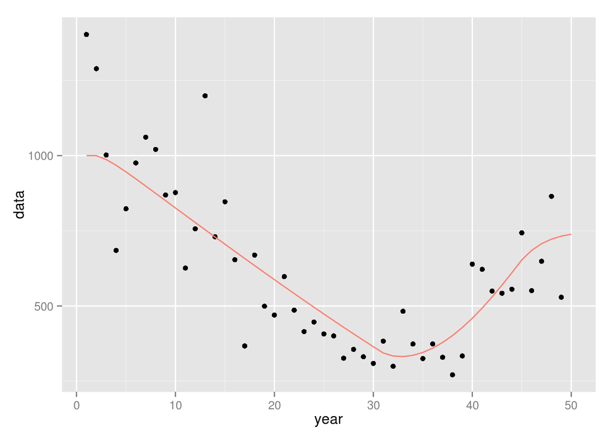

```r
cpue = (stock(bd)[, -dims(bd)$year] + stock(bd)[, -1])/2
cpue = rlnorm(1, log(cpue), 0.2)

ggplot(as.data.frame(cpue)) + geom_point(aes(year, data)) + geom_line(aes(year,
    data), data = as.data.frame(stock(bd)), col = "salmon")
```

Starting values for parameters are also required. These can be set by informed guesses or last years estimates (if you can replicate them). If you know the catch then MSY should be somewhere close and if you can provide a guess for r (the default is 0.5) then carrying capacity (k) can be calculated. The shape by default is assummed to be symetric (i.e. p=1) and $B_0$ ( the ratio of the initial biomass to carrying capacity) could be set to 1 if data are available from the start of the fishery. The robustness of fixing any parameters should be checked.

```r
bd = biodyn(catch = catch(bd), msy = mean(catch(bd)))
```

The constructor estimates the stock based on the initial parameters and catch and so catchability and the CV of the fit of the CPUE index can also be guessed.

```r
setParams(bd) = cpue
params(bd)
```

```
An object of class "FLPar"
params
         r          k          p         b0         q1     sigma1
   0.50000 1000.00000    1.00000    1.00000    0.97059    0.20644
units:  NA
```

The params slot holds the fitted parameters. But before fitting the control slot has to be provided with the initial guesses, upper and lower bounds (min and max) and any difficult to estimate parameters to be fixed (i.e. $B_0$ and p by setting phase=-1). Parameters can also be estimated sequentially by setting phase >0, this allows parameters to be estimated in turn based based on the value of phase.

```r
setControl(bd) = params(bd)

bd@control
```

```
An object of class "FLPar"
        option
params   phase      min        val        max
  r      1.0000e+00 5.0000e-02 5.0000e-01 5.0000e+00
  k      1.0000e+00 1.0000e+02 1.0000e+03 1.0000e+04
  p      1.0000e+00 1.0000e-01 1.0000e+00 1.0000e+01
  b0     1.0000e+00 1.0000e-01 1.0000e+00 1.0000e+01
  q1     1.0000e+00 9.7059e-02 9.7059e-01 9.7059e+00
  sigma1 1.0000e+00 2.0644e-02 2.0644e-01 2.0644e+00
units:  NA
```

## Estimation

Estimation can be performed using maximum likelihood

```r
bdHat = fit(bd, cpue)
```

```
[1] TRUE
```

```r
# plot(biodyns('True'=bd,'Hat'=bdHat))+ theme(legend.position='bottom')
save(bdHat, cpue, file = "/home/laurie/Desktop/bdHat.RData")
```

Since we know the true parameters then we can check why the fit isnt perfect.

```r
params(bdHat)
```

```
An object of class "FLPar"
params
         r          k          p         b0         q1     sigma1
   0.38974 1101.84520    0.58730    1.55864    0.89215    0.19488
units:  NA
```

```r
params(bdHat)%/%params(bd)
```

```
An object of class "FLPar"
params
      r       k       p      b0      q1  sigma1
0.77948 1.10185 0.58730 1.55864 0.91919 0.94400
units:  NA
```

# Residual Patterns

diagnostics are important for transparency, replicability and ensuring that a global solution has actually been found, i.e. that when the assessment is repeated that you get the same solution.

Although biomass dynamic models only use catch and effort data and estimate a few parameters, the same diagnstics are required when comparing fits from statistical catch-at-size models with potentially 1000s of parameters.

Patterns in residuals of the fits to the CPUE and stock abundnace may indicate a violation of models assumptions. Residuals and covariates are in the diags slot.

The residuals are found in the diags slot.

```r
rsdl = bdHat@diags

head(rsdl)
```

```
  year stock catch  index    hat stockHat residual residualLag     qqx
1    1  1548  0.00 1402.9 1380.8     1548  0.01586     0.10003  0.1025
2    2  1307 12.93 1289.1 1166.4     1307  0.10003    -0.06226  0.5962
3    3  1195 25.53 1001.9 1066.3     1195 -0.06226    -0.38163 -0.4780
4    4  1124 37.55  684.9 1003.1     1124 -0.38163    -0.14984 -1.6350
5    5  1072 48.93  823.3  956.4     1072 -0.14984     0.06094 -0.8637
6    6  1029 59.65  975.6  918.0     1029  0.06094     0.18266  0.4780
       qqy    qqHat  harvest
1  0.01586  0.01889 0.000000
2  0.10003  0.11129 0.009384
3 -0.06226 -0.08975 0.020641
4 -0.38163 -0.30629 0.032549
5 -0.14984 -0.16193 0.044676
6  0.06094  0.08916 0.056872
```

Violation of the assumptions may result in biased estimates of parameters, reference points and stock trends. In addition variance estimates obtained from bootstrapping assume that residuals are Independently and Identically Distributed (i.i.d.).

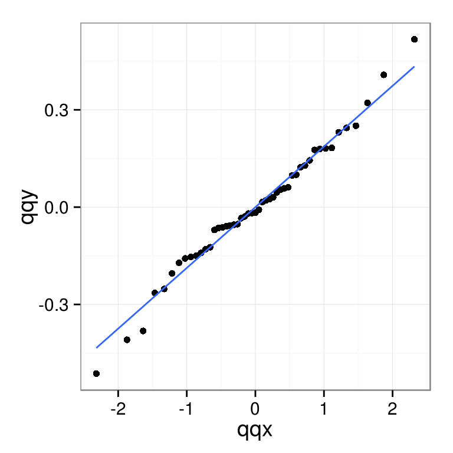

```r
ggplot(rsdl) + geom_point(aes(qqx, qqy)) + stat_smooth(aes(qqx, qqHat), method = "lm",
    se = T, fill = "blue", alpha = 0.1) + theme_ms(14, legend.position = "bottom")
```

## Observed against Fitted

It is assumed that an index is proportional to the stock so when plotting the observed against the fitted values the points should fall around the $y=x$ line, if they do not then the index may not be a good proxy for the stock trend.

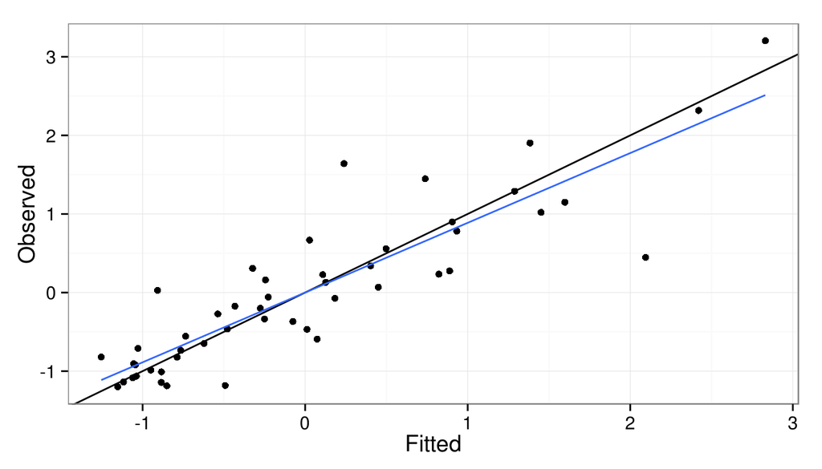

```r
ggplot(with(rsdl, data.frame(obs = stdz(index), hat = stdz(hat)))) + geom_abline(aes(0,
    1)) + geom_point(aes(obs, hat)) + stat_smooth(aes(obs, hat), method = "lm",
    se = F) + theme_ms(14, legend.position = "bottom") + xlab("Fitted") + ylab("Observed")
```

## Year Patterns

Next the residuals are plotted agianst year along with a lowess smoother to see if the proxy for the stock doesnt agree with the estimated stock trend,

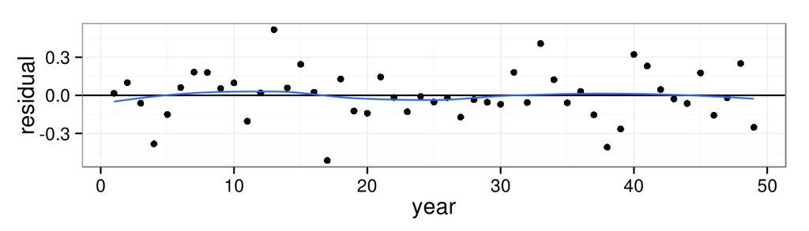

```r
dat = transform(subset(rsdl, !is.na(residual), residual = stdz(residual, na.rm = T)))
ggplot(aes(year, residual), data = dat) + geom_hline(aes(yintercept = 0)) +
    geom_point() + stat_smooth(method = "loess", se = F) + theme_ms(14, legend.position = "bottom")
```

## Variance

It is also assumed that variance does not vary with the mean, this assumption can be checked by plotting the residuals against the fitted values.

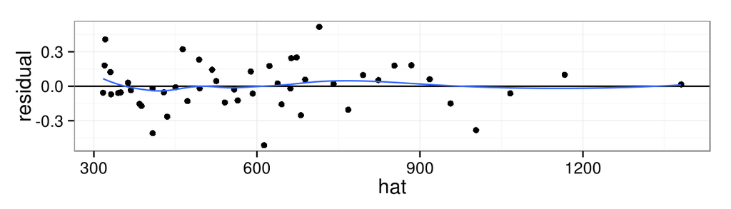

```r
ggplot(aes(hat, residual), data = subset(rsdl, !is.na(hat) & !is.na(residual))) +
    geom_hline(aes(yintercept = 0)) + geom_point() + stat_smooth(method = "loess",
    se = F) + theme_ms(14, legend.position = "bottom")
```